# Principal component analysis (PCA)

70-467 Machine Learning for Business Analytics

Professor: Andrés Castaño Zuluaga

## Which items should Starbucks drop, and what should it add?

Which items are alike?

What kind of item is missing?

Sales name the weak sellers. Calories, fat, carb, fiber and protein are how we tell which items are alike.

Can two numbers per item, built from these five variables, show which items are alike and what kind of item is missing?

## What do we know about each item?

One observation is one food item: 77 items of 7 types. 41 are bakery items.

| Variable | Type | Unit | Description |
| --- | --- | --- | --- |
| item | text | none | Name on the menu board |
| type | text | none | bakery, bistro box, hot breakfast, parfait, petite, salad or sandwich |
| calories | integer | calories | Energy in one item |
| fat | numeric | g | Fat in one item |
| carb | integer | g | Carbohydrate in one item |
| fiber | integer | g | Fiber in one item |
| protein | integer | g | Protein in one item |

Data: starbucks, OpenIntro.

There is nothing to predict here. What would a menu team want from these five numbers?

## Where are we on the course roadmap?

|  | Description | Tools | Use |
| --- | --- | --- | --- |
| Predict & evaluate |  |  |  |
| Linear regression | Predict a number | OLS |  |
| Metrics | Size of the errors | RMSE, R² |  |
| Train/test + leakage | Predict without fooling ourselves | Holdout |  |
| Regularization | Shrink complexity | Ridge, lasso |  |
| Cross-validation | Choose λ without touching test | k-fold |  |
| Classify & decide |  |  |  |
| Logistic | A probability, not a class | Log-odds |  |
| Thresholds | A score is not an action | ROC, threshold |  |
| Flexible & unsupervised |  |  |  |
| Trees | When linearity fails | Splits | Split the hours into simple regions. |
| Forests / boosting | One ensemble | Random forest, boosting |  |
| PCA | Compress X, no Y | PCs | Place every item on a map with two numbers. |
| Clustering | Segment without Y | K-means |  |

What will we do in this topic?

## What we will do

1. Why reduce dimensions?
2. What does PCA do?
3. How should you input data for PCA?
4. How to interpret the outputs from PCA?
5. What are the outputs from PCA?
6. When is PCA not useful?

## Which two numbers move together most?

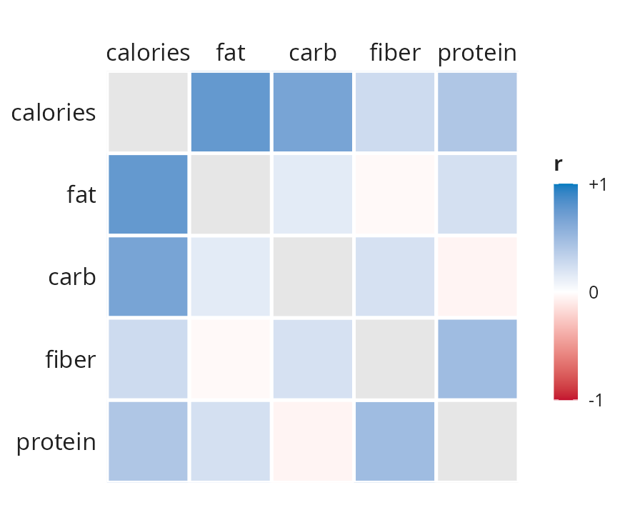

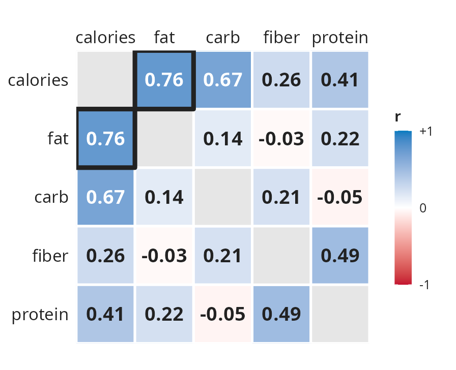

Which two numbers rise and fall together most?

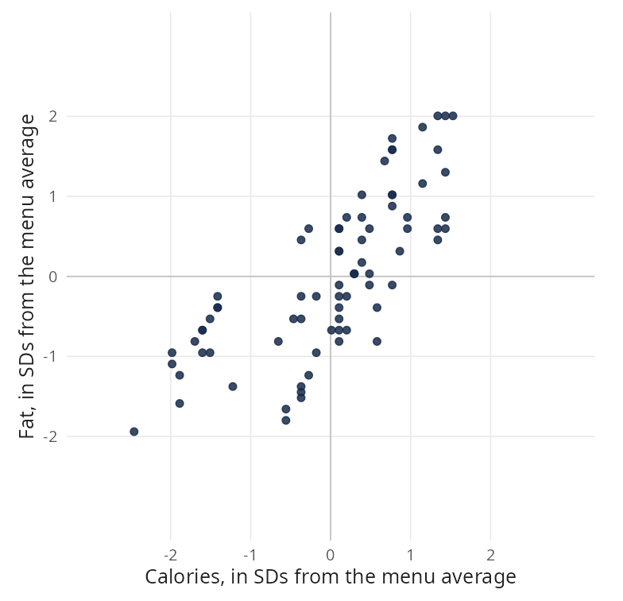

Units: calories in calories; fat, carb, fiber and protein in grams. All per item.

## Which line maximizes the variance of the 77 items?

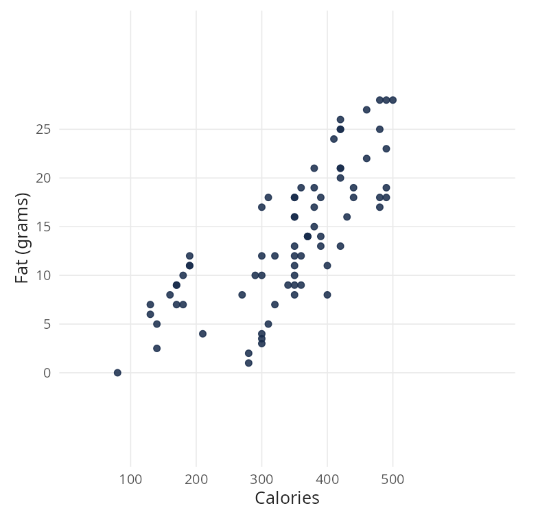

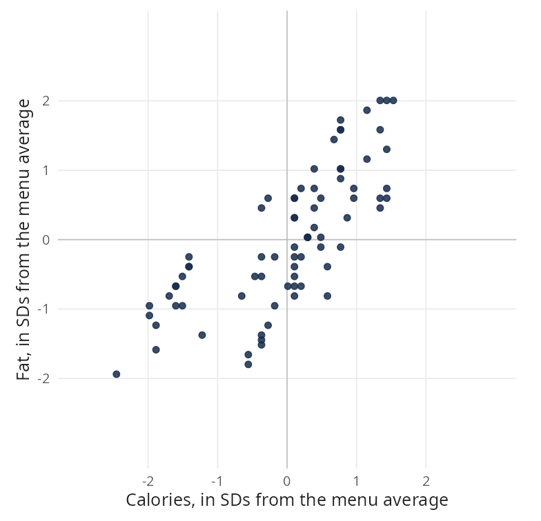

Which line maximizes the variance of the 77 items?

## What do we keep and what do we lose for one item?

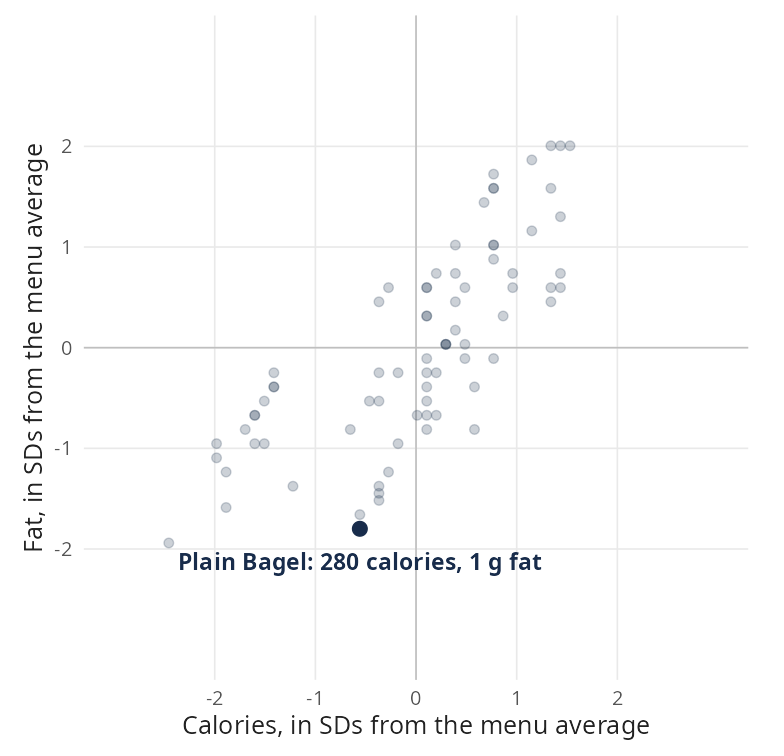

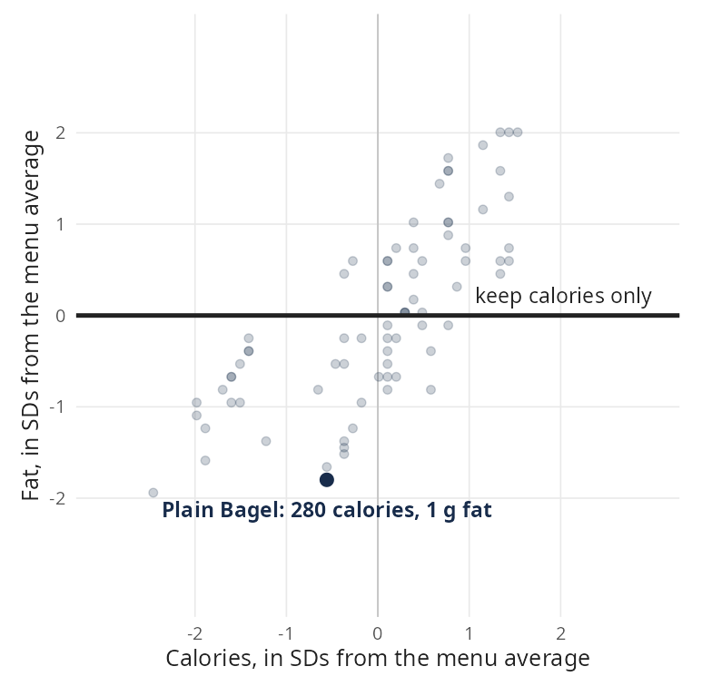

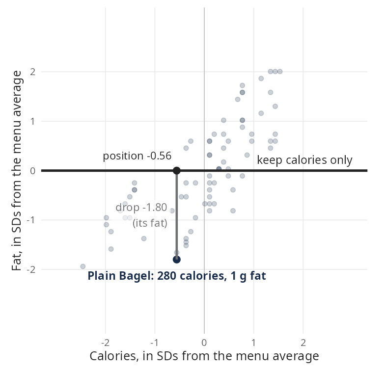

If we keep only calories, what do we lose for the Plain Bagel?

## Which line keeps the most?

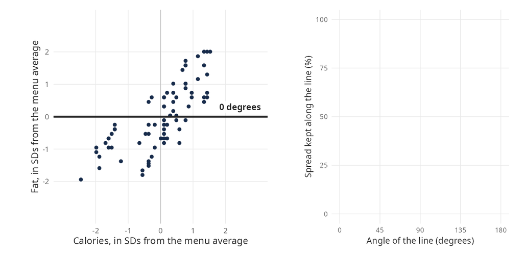

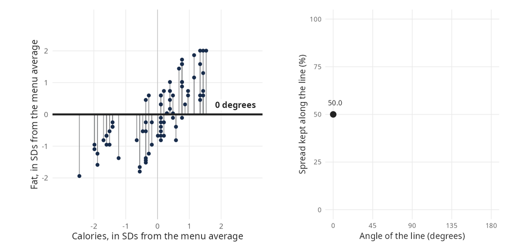

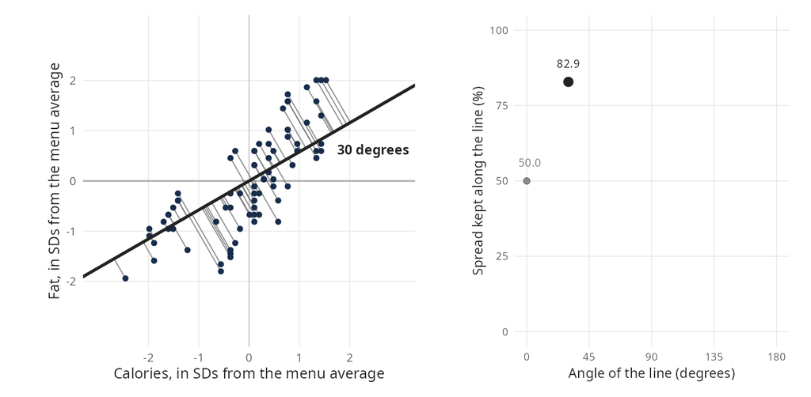

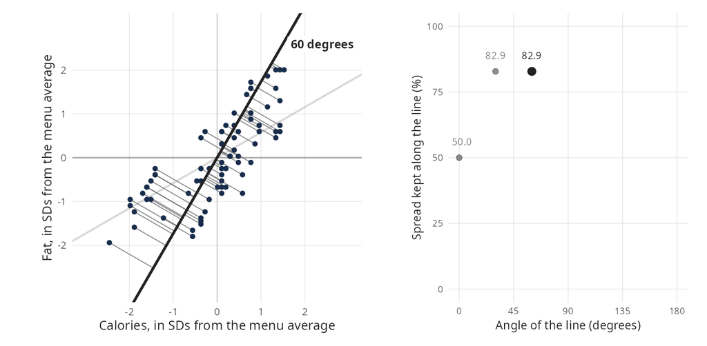

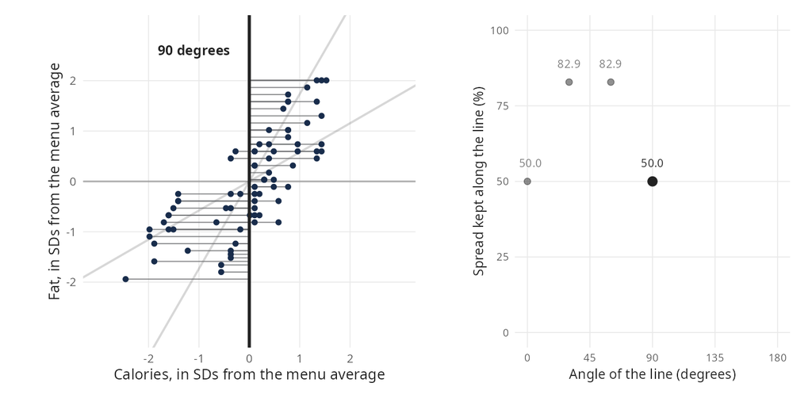

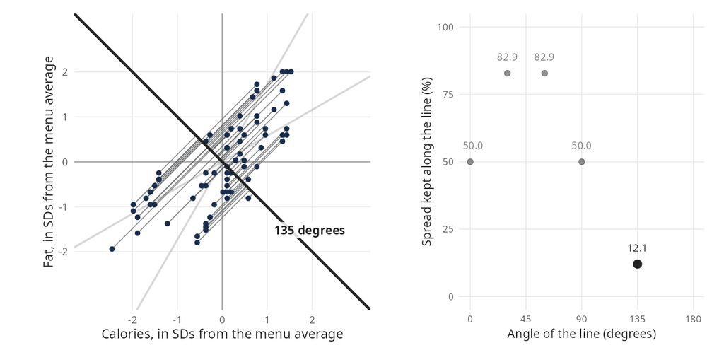

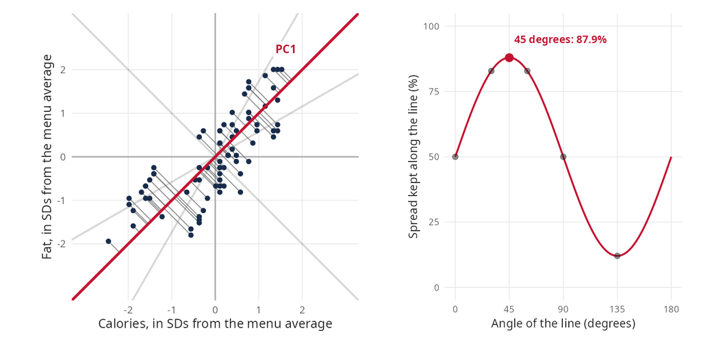

Which angle keeps the most? Point to it on the panel.

The first principal component of a set of features $X_1, X_2, \dots, X_p$ is the normalized linear combination of the features $\textcolor{#c41230}{Z_1} = \textcolor{#c41230}{\phi_{11}} X_1 + \textcolor{#c41230}{\phi_{21}} X_2 + \dots + \textcolor{#c41230}{\phi_{p1}} X_p$ that has the largest variance. By normalized, we mean that $\sum_{j=1}^{p} \textcolor{#c41230}{\phi_{j1}}^2 = 1$. We refer to the elements $\textcolor{#c41230}{\phi_{11}}, \dots, \textcolor{#c41230}{\phi_{p1}}$ as the loadings of the first principal component.

$\textcolor{#c41230}{Z_1}$ = 0.707 × (calories in SDs) + 0.707 × (fat in SDs); each loading is $1/\sqrt{2} \approx 0.707$, and the squares sum to 1.

Plain Bagel: 0.707 × (−0.56) + 0.707 × (−1.80) = −1.67.

## What does a second number add?

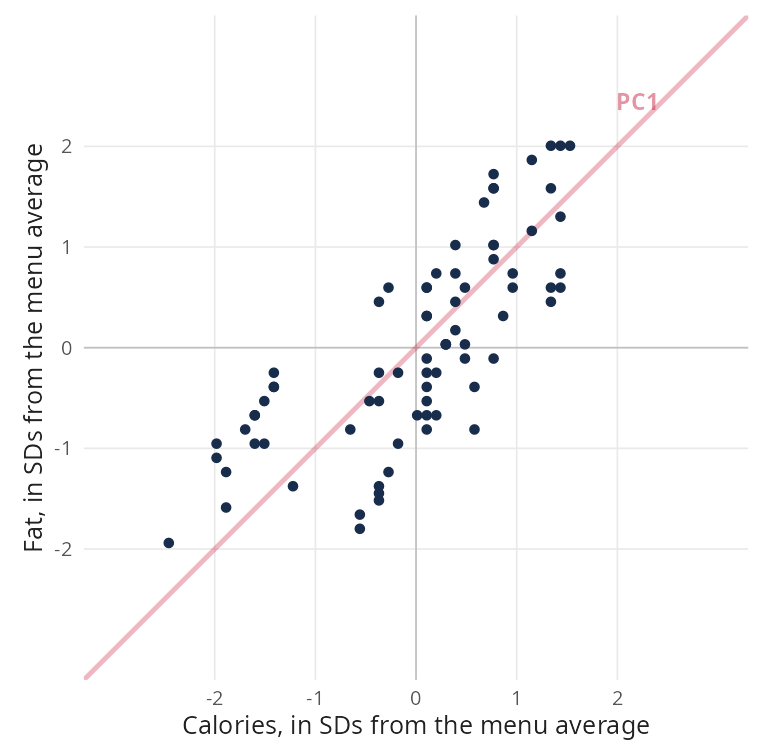

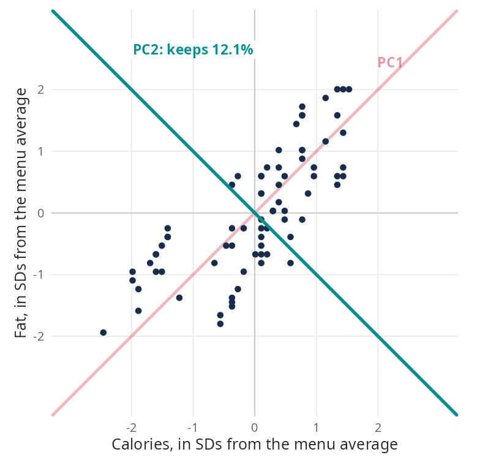

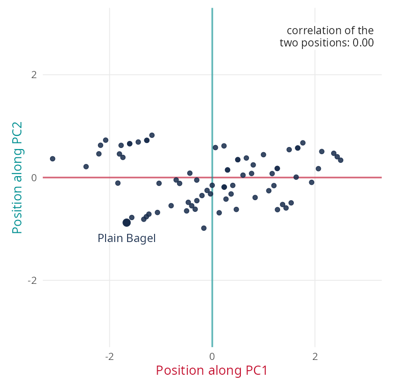

If you may keep a second number, which line would you draw?

The second principal component is the linear combination of $X_1, \dots, X_p$ that has maximal variance out of all linear combinations that are uncorrelated with $\textcolor{#c41230}{Z_1}$.

with $\sum_{j=1}^{p} \textcolor{#008f91}{\phi_{j2}}^2 = 1$

$\textcolor{#008f91}{Z_2}$ = −0.707 × (calories in SDs) + 0.707 × (fat in SDs).

Plain Bagel: −0.88.

## What changes with all five numbers?

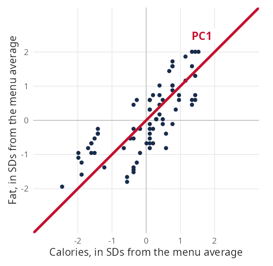

$$\textcolor{#c41230}{Z_1} = \textcolor{#c41230}{\phi_{11}} X_1 + \textcolor{#c41230}{\phi_{21}} X_2 + \dots + \textcolor{#c41230}{\phi_{p1}} X_p, \quad \text{with } \sum_{j=1}^{p} \textcolor{#c41230}{\phi_{j1}}^2 = 1$$

For the menu:

Z<sub>1</sub> = φ<sub>11</sub>calories + φ<sub>21</sub>fat + φ<sub>31</sub>carb + φ<sub>41</sub>fiber + φ<sub>51</sub>protein

If we skip the standard deviations and use the units on the file, which variable will PC1 follow?

## Does the unit decide the answer?

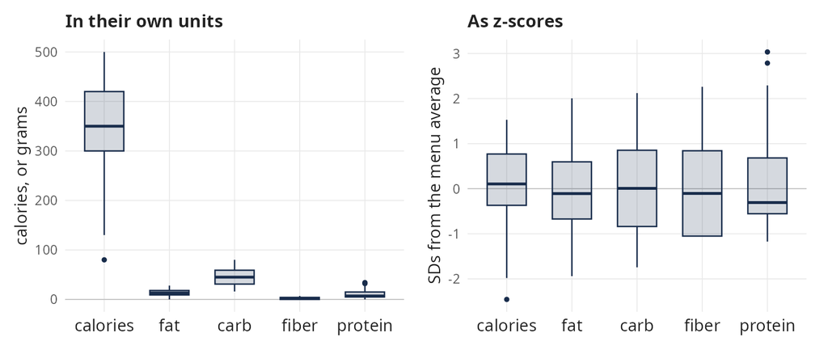

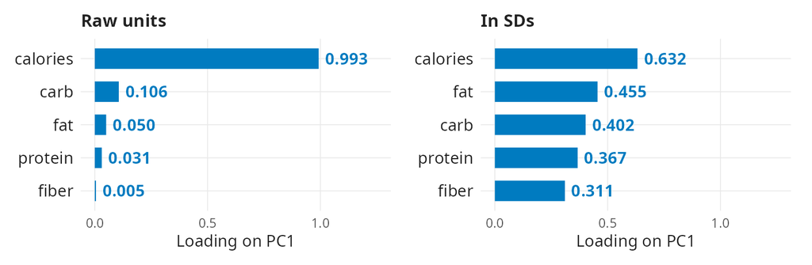

Raw units: PC1 keeps 98.0% and is almost only calories. In SDs: PC1 keeps 46.8%.

Why does PC1 follow calories?

z-score: $z = (x - \text{mean}) / \text{SD}$. Plain Bagel: (280 − 338.8) / 105.4 = −0.56.

## What does PCA maximize?

The weights: how much each number counts in an item's position on PC1.

0.632calories

0.455fat

0.402carb

0.311fiber

0.367protein

Plain Bagel (in SDs)

| 0.632 | × (−0.56) | = | −0.35 | calories |
| --- | --- | --- | --- | --- |
| 0.455 | × (−1.80) | = | −0.82 | fat |
| 0.402 | × 0.85 | = | +0.34 | carb |
| 0.311 | × (−0.10) | = | −0.03 | fiber |
| 0.367 | × (−0.06) | = | −0.02 | protein |
| Position on PC1 |  |  | **−0.88** |  |

| Weights on calories, fat, carb, fiber, protein | Spread of the 77 positions | Share of the total, 5 |
| --- | --- | --- |
| Calories only: 1, 0, 0, 0, 0 | 1.00 | 20.0% |
| Equal: 0.447 each | 2.24 | 44.8% |
| PCA: 0.632, 0.455, 0.402, 0.311, 0.367 | **2.34** | **46.8%** |

PCA’s weights spread the items the most. That’s how they’re chosen. Do equal weights come close, or fall far behind?

Double every weight: every position doubles, and the spread is 4 times bigger (2.342 becomes 9.368), with the items in the same order. Bigger weights would always win. So we **fix the length**: the squared weights add to 1.

$$\underset{\phi_{11},\dots,\phi_{p1}}{\text{maximize}}\; \underbrace{\frac{1}{n-1}\sum_{i=1}^{n} \textcolor{#c41230}{z_{i1}^{2}}}_{\text{spread of the positions}} \;\; \text{subject to} \; \underbrace{\sum_{j=1}^{p} \textcolor{#c41230}{\phi_{j1}^{2}} = 1}_{\text{fixed length}}$$

$$\textcolor{#c41230}{z_{i1}} = \textcolor{#c41230}{\phi_{11}} x_{i1} + \dots + \textcolor{#c41230}{\phi_{p1}} x_{ip} \quad \text{(item } i\text{'s position)}$$

Five numbers in SDs, each with spread 1: a total of 5. PC1 keeps 2.342 of 5 = 46.8%.

## What does PC1 measure?

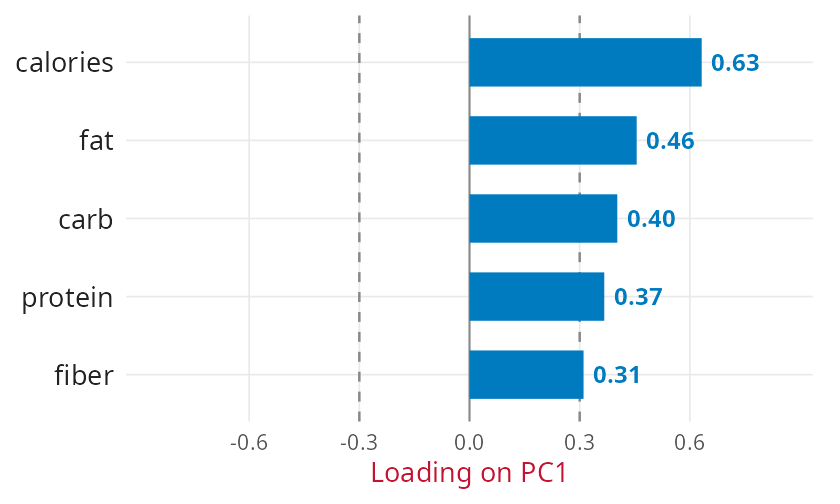

PC1 = ______

PC1 = how big the item is

All five loadings are positive. Name PC1 in two or three words.

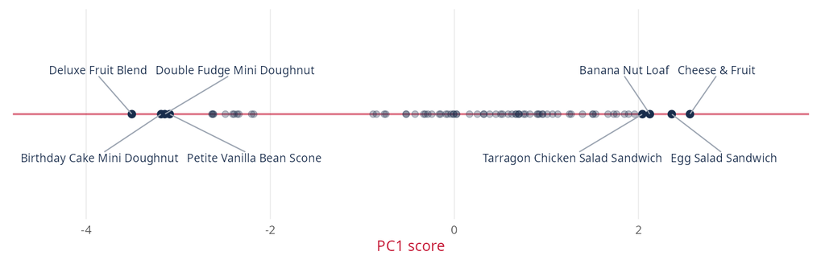

## What does PC2 measure?

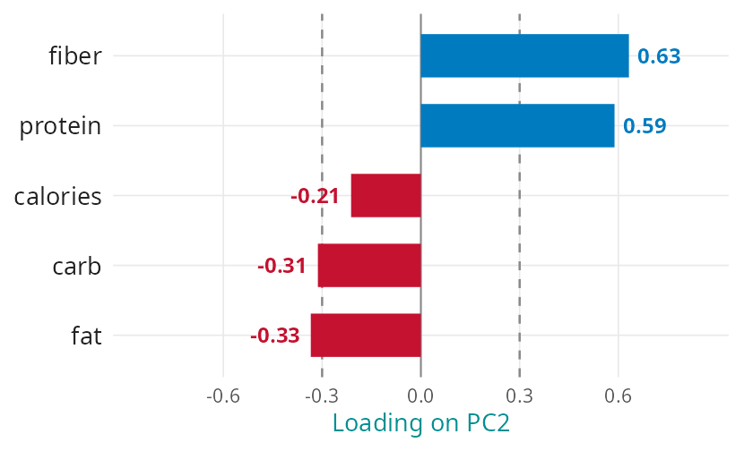

PC2 = ______

PC2 = filling vs indulgent

With your neighbour, two minutes: name PC2. Do any of the words you wrote for question 3 fit?

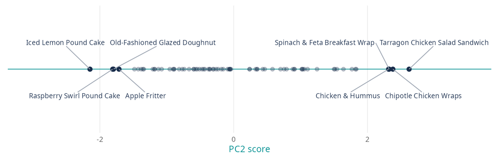

## Where does each item sit on the menu map?

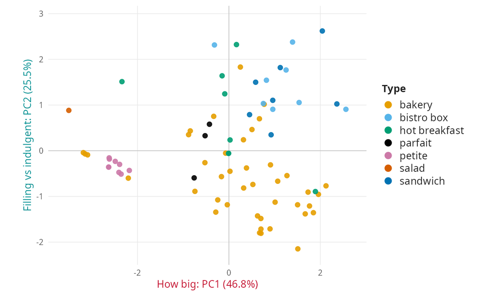

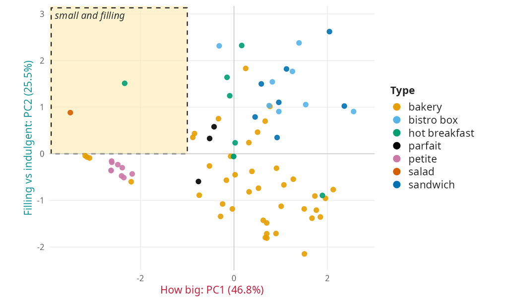

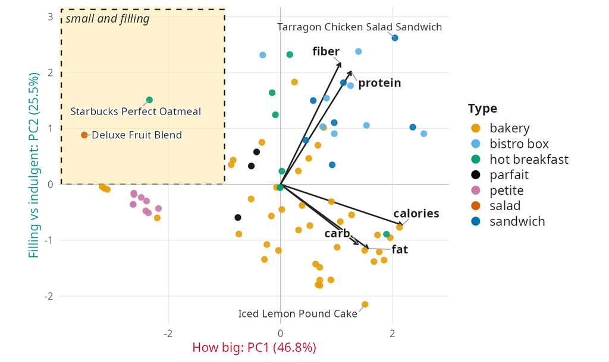

Which part of the map is nearly empty? What would you add to the menu?

A plot of the items and the loadings together is a biplot.

## How many components should we keep?

[figure not shown]

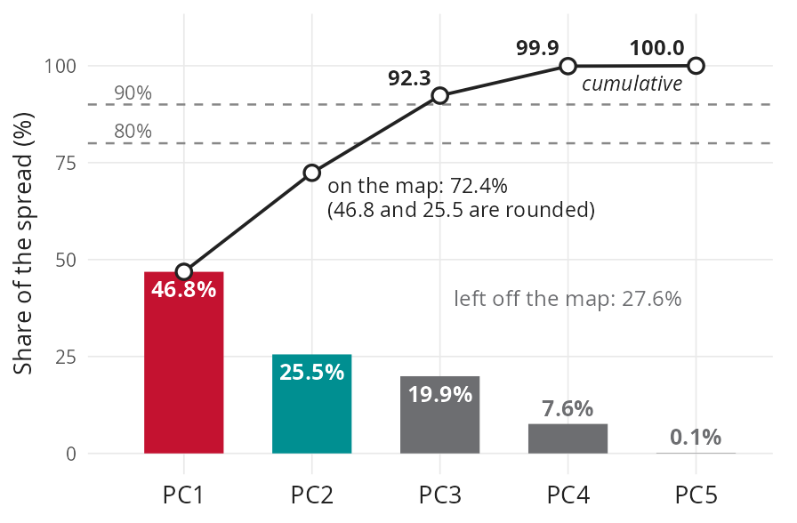

How much of the spread will our two-number map keep?

Proportion of variance explained (PVE) of PC1 = variance of $\textcolor{#c41230}{Z_1}$ / total variance = 2.342 / 5 = 46.8%.

A plot of the PVE of each component is a scree plot.

Would you keep two components or three?